# Exploratory Data Analysis

Matthew Versace, Sharna McClure & Ciara Stevens-Baytopp

## Introduction

This following exploratory data analysis (EDA) will examine log returns from 2014-2024, for four ASX-listed stocks: CBA, BHP, CSL, and WES. Data was sourced from Yahoo Finance using the R “quantmod” package and uses daily adjusted closing prices for sufficient observations and comprehensive analysis.

## 1. Stock analysis

The series is merged to observe the log return movements all together. We expect the returns to be close to zero under standard efficient market hypothesis (EMH) assumptions and verify this with the following code:

```r
summary(lr)
```

```
##      Index                 cba                  bhp
##  Min.   :2014-01-02   Min.   :-0.1054276   Min.   :-0.1556533
##  1st Qu.:2016-10-01   1st Qu.:-0.0059222   1st Qu.:-0.0094841
##  Median :2019-07-06   Median : 0.0008131   Median : 0.0003333
##  Mean   :2019-07-03   Mean   : 0.0004463   Mean   : 0.0003484
##  3rd Qu.:2022-03-30   3rd Qu.: 0.0075284   3rd Qu.: 0.0107672
##  Max.   :2024-12-30   Max.   : 0.1245326   Max.   : 0.1128326
##       wes                  csl
##  Min.   :-0.1043070   Min.   :-0.1092874
##  1st Qu.:-0.0057070   1st Qu.:-0.0064749
##  Median : 0.0009175   Median : 0.0006935
##  Mean   : 0.0005286   Mean   : 0.0005624
##  3rd Qu.: 0.0072665   3rd Qu.: 0.0081168
##  Max.   : 0.1069406   Max.   : 0.1176931
```

```r
summary(market_lr)
```

```
##      Index                ASX200
##  Min.   :2014-01-02   Min.   :-0.1020303
##  1st Qu.:2016-10-01   1st Qu.:-0.0043284
##  Median :2019-07-06   Median : 0.0007189
##  Mean   :2019-07-03   Mean   : 0.0001506
##  3rd Qu.:2022-03-30   3rd Qu.: 0.0051753
##  Max.   :2024-12-30   Max.   : 0.0676648
```

Observing the mean values of all stocks, this is consistent with theoretical expectations of EMH. Numbers greater than zero suggest that returns can be predictable.

We conduct a visual inspection by plotting the log returns to analyse their volatility in the market.

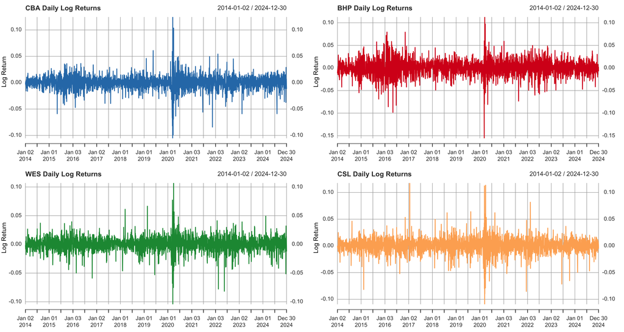

All stocks experience a cluster of volatility during the COVID-19 pandemic and the recovery period shortly after (RBA hiking cycle). The charts each reflect the differences in all industries, for example, pharmaceuticals and mining appear to exhibit more volatility at the beginning of the series compared to the financial and retail industry at this same period of time.

Similarly we examine the benchmark index (ASX 200)

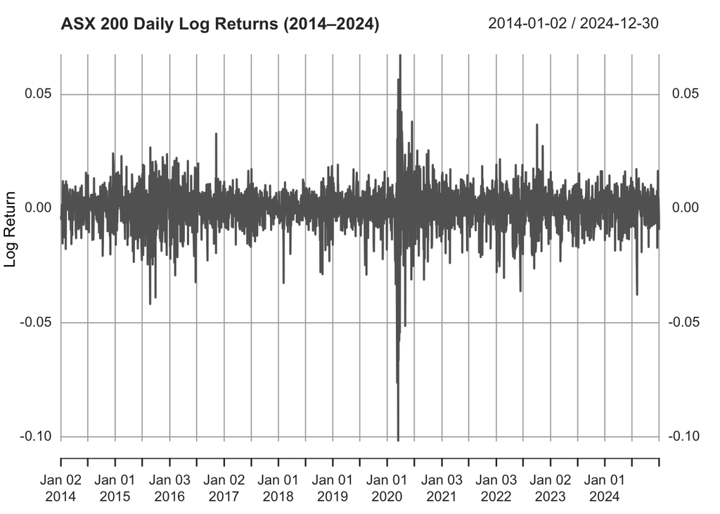

We observe a similar pattern to the four stocks, all of which appear to track the index with some deviations due to industry specific conditions.

## 2. Data Characteristics

We employ the Jarque-Bera (JB) test to observe if the log returns follow a normal distribution, using hypothesis testing with two degrees of freedom. It also helps to measure for skewness of the distributions, and kurtosis (the likelihood of extreme events from the center of the distribution).

The decision rule is:

$$H_0: \text{The sample data are normally
distributed} \ (S = 0, \ K = 3)$$
$$H_1: \text{The sample data are not normally
distributed} \ (S \neq 0, \ K \neq 3)$$

Where S = Skewness and K = Kurtosis.

```
## cba — JB Statistic: 13673.45 | p-value: 0e+00
## bhp — JB Statistic: 2463.27 | p-value: 0e+00
## wes — JB Statistic: 7212.17 | p-value: 0e+00
## csl — JB Statistic: 9827.63 | p-value: 0e+00
```

```
##   Stock Skewness Kurtosis
## 1   cba  -0.2195  13.8559
## 2   bhp  -0.2583   7.5824
## 3   wes  -0.4489  10.8395
## 4   csl  -0.0017  12.2110
```

Following the previous results, all stocks are negatively skewed and kurtosis is > 0, suggesting the tails of the distribution are thick. This is consistent with the previous evidence of non-normality.

We now test for stationarity of the log returns. This a key assumption that must be satisfied for the reliability of standard errors in the next regression models. To test for stationarity we use the Augmented Dickey-Fuller (ADF) test which determines if properties such as mean or variance change over time.

The decision rule is:

$$\text{Reject } H_0 \text{ if }
p\text{-value} < 0.05$$

```
## cba — ADF p-value: 0.01
##
##  Augmented Dickey-Fuller Test
##
## data:  as.numeric(lr[, i])
## Dickey-Fuller = -14.039, Lag order = 14, p-value = 0.01
## alternative hypothesis: stationary
```

```
## bhp — ADF p-value: 0.01
##
##  Augmented Dickey-Fuller Test
##
## data:  as.numeric(lr[, i])
## Dickey-Fuller = -14.577, Lag order = 14, p-value = 0.01
## alternative hypothesis: stationary
```

```
## wes — ADF p-value: 0.01
##
##  Augmented Dickey-Fuller Test
##
## data:  as.numeric(lr[, i])
## Dickey-Fuller = -14.429, Lag order = 14, p-value = 0.01
## alternative hypothesis: stationary
```

```
## csl — ADF p-value: 0.01
##
##  Augmented Dickey-Fuller Test
##
## data:  as.numeric(lr[, i])
## Dickey-Fuller = -13.506, Lag order = 14, p-value = 0.01
## alternative hypothesis: stationary
```

The results of the ADF test show a p-value of 0.01 for all log returns of the stocks. There is sufficient evidence to reject the null hypothesis at the 5% significance level, concluding that the data is stationary.

## 3. Multivariable Analysis

We begin examining how variables move together with a correlation plot.

```
## CORRELATION MATRIX
```

```
##       cba   bhp   wes   csl
## cba 1.000 0.401 0.542 0.395
## bhp 0.401 1.000 0.310 0.208
## wes 0.542 0.310 1.000 0.458
## csl 0.395 0.208 0.458 1.000
```

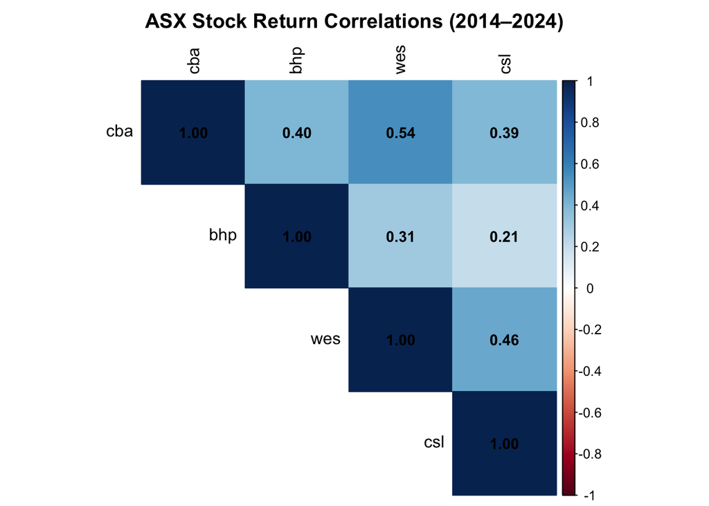

CBA notably exhibits a positive correlation with WES at 0.54 which may raise some concern for multicollinearity. In contrast, most other stocks show a weaker positive correlation which should not be of concern.

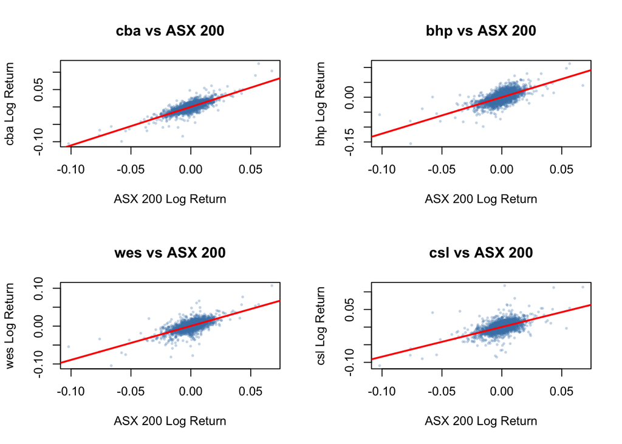

The above plots demonstrate returns plotted against the ASX 200. Most of the log returns are clustered with some extremes as identified before, and there is a strong positive relationship with the ASX index. This satisfies the assumption of stocks reflecting the prescence of marekt (systematic) risk, a key assumption of the regression models that will be used in formal analysis.

## 4. Behavioural Variable Analysis

```
##         date           cba          bhp           wes           csl
## 1 2014-01-02 -0.0033455593 -0.011320341 -0.0015903919  0.0001452784
## 2 2014-01-05  0.0002576686 -0.005575503 -0.0079898861 -0.0033473552
## 3 2014-01-06  0.0015451372 -0.009362101  0.0009162932 -0.0024810430
## 4 2014-01-07  0.0020565623 -0.004578997  0.0057084173 -0.0017550773
## 5 2014-01-08  0.0012834976 -0.001891894  0.0031822421 -0.0013182989
## 6 2014-01-09 -0.0048851971 -0.014439749 -0.0002266746 -0.0049965372
##       market_lr
## 1 -0.0033214818
## 2 -0.0047213568
## 3 -0.0014846792
## 4 -0.0001880937
## 5  0.0015788700
## 6 -0.0022563187
```

```
## [1] 2780
```

Also factored into our regression models will be behavioural characteristics of momentum (Jegadeesh & Titman 1993) and overreaction (De Bondt & Thaler, 1985) observed in behavioural finance. We construct the momentum variable by taking the 20-day cumulative log return lagged by one trading day, and examined days where returns exceed two standard deviations from the mean in the overreaction variable.

```
## MOMENTUM VARIABLE SUMMARY
```

```
## cba — Mean: 0.009308 | SD: 0.055652
## bhp — Mean: 0.007399 | SD: 0.073672
## wes — Mean: 0.010932 | SD: 0.052971
## csl — Mean: 0.011252 | SD: 0.054857
```

In the momentum table summary, the results show positive trending returns over a 20-day period for all stocks. CSL has the highest mean (strongest momentum) which reflects good performance over this period. On the other hand, BHP has the largest variance in its returns, this is consistent with volatility of commodity prices. Further analysis will confirm whether investors are over or under-reacting to information.

```
## OVERREACTION DAYS
```

```
## cba — Large positive days: 50 | Large negative days: 61
## bhp — Large positive days: 66 | Large negative days: 65
## wes — Large positive days: 53 | Large negative days: 74
## csl — Large positive days: 57 | Large negative days: 66
```